# BCO6007: Week 5 Tutorial

Maria Prokofieva

15/01/2020

# Week 5: Dealing with different datatypes

## Objectives

1. get to know different types of data and how to deal with basic ones
2. use data for further analysis using `tidyverse` with reference to different data types
3. being able to work with dates and transform dates
4. being able to use visualizations for different data types

We continue using `tidyverse` package, so please make sure that you `library(tidyverse)`.

We are also going to look at a few other packages to help us do `fancy things` in our data analysis

If you are totally new and never use `tidyverse` please make sure you `install.packages("tidyverse")`.

Today we are going to work with another datasets from `Tidy Tuesday`. You can read about this fantastic project [here](https://github.com/rfordatascience/tidytuesday)

and I highly encourage you to participate in their weekly challenges!

Today, we are looking at one of the earlier ones [here](https://github.com/rfordatascience/tidytuesday/blob/master/data/2020/2020-03-31/readme.md. Let’s have a look at it

The “inspiration” for this tutorial comes from [David Robinson](https://www.youtube.com/watch?v=1R4X09w7tQ8&t=112s), once again! He is fantastic and his data analytics skills are so inspirational!

*References*:

- Chapters 15-16: R for Data Science. Garrett Grolemund and Hadley Wickham [Link](https://r4ds.had.co.nz/factors.html)

The “inspiration” for this tutorial comes from [David Robinson](https://www.youtube.com/watch?v=1R4X09w7tQ8&t=112s), once again! He is fantastic and his data analytics skills are so inspirational!

```r
library(tidyverse)
library(lubridate)
theme_set(theme_light())

brewing_materials <- read_csv('https://raw.githubusercontent.com/rfordatascience/tidytuesday/master/data/2020/2020-03-31/brewing_materials.csv') %>%
  mutate(date = ymd(paste(year, month, 1))) %>%
  filter(year < 2016)
beer_taxed <- read_csv('https://raw.githubusercontent.com/rfordatascience/tidytuesday/master/data/2020/2020-03-31/beer_taxed.csv')
brewer_size <- read_csv('https://raw.githubusercontent.com/rfordatascience/tidytuesday/master/data/2020/2020-03-31/brewer_size.csv')
beer_states <- read_csv('https://raw.githubusercontent.com/rfordatascience/tidytuesday/master/data/2020/2020-03-31/beer_states.csv')
```

### What ingredients are used in US beer production?

We will be working with `strings` using `str_detect()` function. Please use `Help` to locate this function and have a look it and examples.

We are also going to use `fct_reorder` for data viz

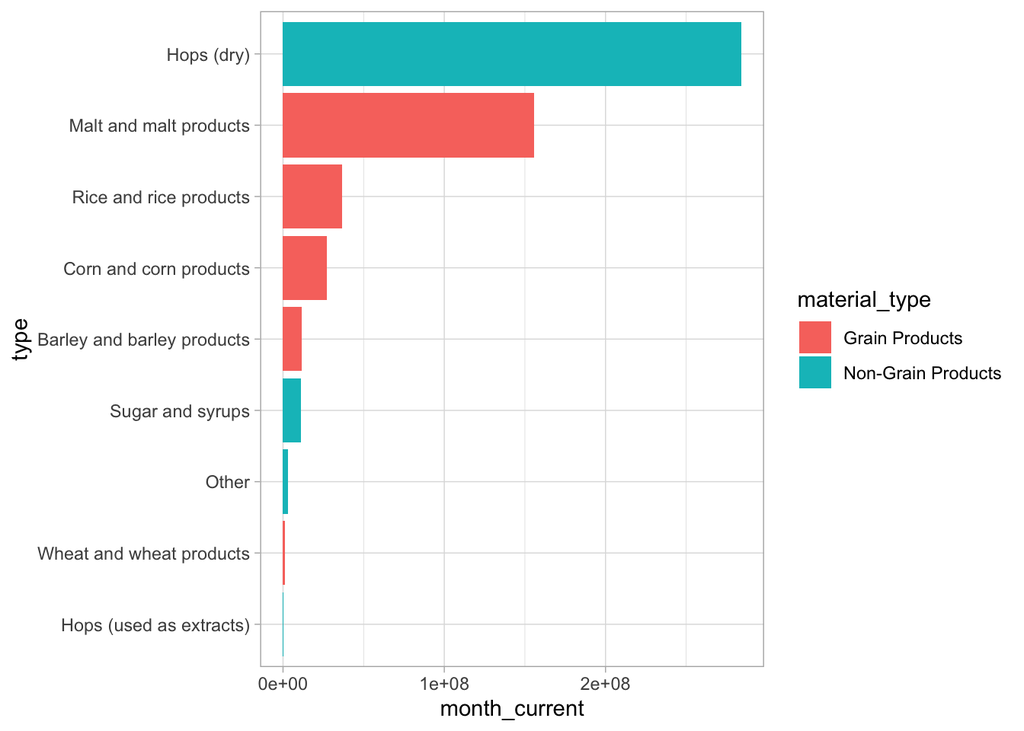

```r
brewing_materials %>%
  filter(date == max(date)) %>%
  filter(!str_detect(material_type, "Total")) %>%
  mutate(type = fct_reorder(type, month_current)) %>%
  ggplot(aes(type, month_current, fill = material_type)) +
  geom_col() +
  coord_flip()
```

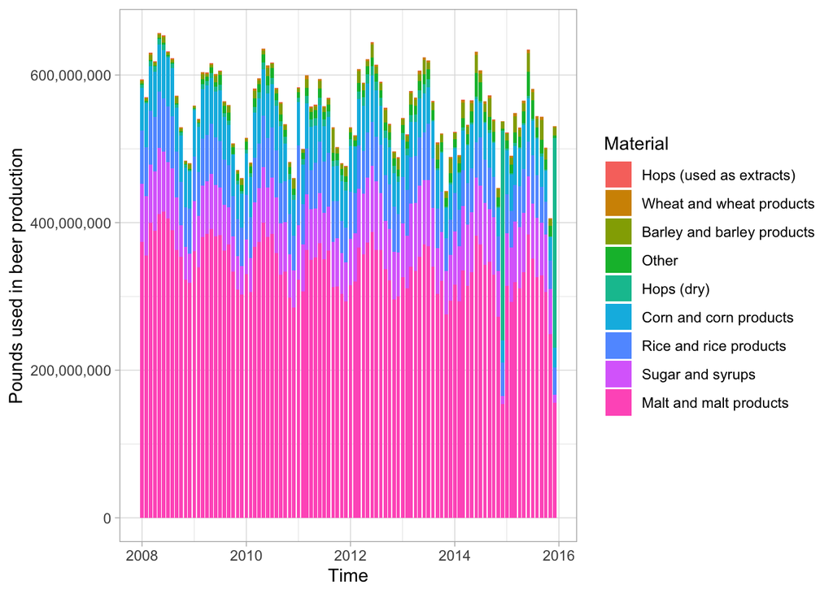

```r
library(lubridate)
brewing_materials %>%
  filter(!str_detect(material_type, "Total")) %>%
  mutate(type = fct_reorder(type, month_current, sum)) %>%
  ggplot(aes(date, month_current, fill = type)) +
  geom_col() +
  scale_y_continuous(labels = scales::comma) +
  labs(x = "Time",
       y = "Pounds used in beer production",
       fill = "Material")
```

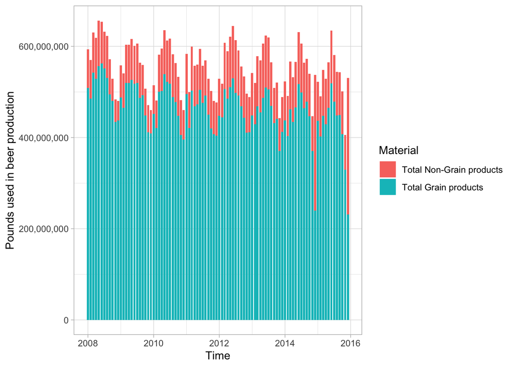

```r
brewing_materials %>%
  filter(str_detect(material_type, "Total.*products")) %>%
  mutate(type = fct_reorder(type, month_current, sum)) %>%
  ggplot(aes(date, month_current, fill = type)) +
  geom_col() +
  scale_y_continuous(labels = scales::comma) +
  labs(x = "Time",
       y = "Pounds used in beer production",
       fill = "Material")
```

### Brewer size distribution

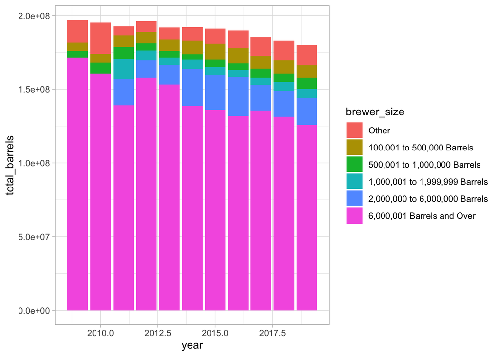

```r
brewer_size %>%
  filter(brewer_size != "Total", !is.na(total_barrels)) %>%
  mutate(brewer_size = fct_lump(brewer_size, 5, w = total_barrels),
         barrel_number = coalesce(parse_number(as.character(brewer_size)), 1),
         brewer_size = fct_reorder(brewer_size, barrel_number)) %>%
  ggplot(aes(year, total_barrels, fill = brewer_size)) +
  geom_col()
```

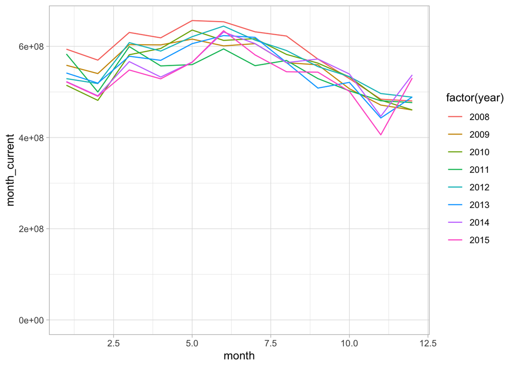

```r
brewing_materials %>%
  filter(material_type == "Total Used") %>%
  ggplot(aes(month, month_current, color = factor(year))) +
  geom_line() +
  expand_limits(y = 0)
```

Where is beer produced?

```r
beer_states %>%
  count(type, sort = TRUE, wt = barrels)
```

```
## # A tibble: 3 x 2
##   type                       n
##   <chr>                  <dbl>
## 1 Bottles and Cans 3790640995.
## 2 Kegs and Barrels  413060363.
## 3 On Premises        32942944.
```

```r
beer_states %>%
  group_by(year) %>%
  summarize(barrels = sum(barrels, na.rm = TRUE))
```

```
## # A tibble: 12 x 2
##     year    barrels
##    <dbl>      <dbl>
##  1  2008 369365660.
##  2  2009 366722996
##  3  2010 362423267.
##  4  2011 356149025.
##  5  2012 360802673.
##  6  2013 356172814.
##  7  2014 354773849.
##  8  2015 352082099.
##  9  2016 348860505.
## 10  2017 341358612.
## 11  2018 333778335.
## 12  2019 334154466.
```

```r
# Who consumes beer on premises
state_percents_2019 <- beer_states %>%
  filter(year == max(year), state != "total") %>%
  group_by(state, year) %>%
  mutate(percent = barrels / sum(barrels)) %>%
  ungroup()
state_percents_2019 %>%
  filter(type == "On Premises") %>%
  arrange(desc(percent))
```

```
## # A tibble: 51 x 5
##    state  year barrels type        percent
##    <chr> <dbl>   <dbl> <chr>         <dbl>
##  1 ND     2019  10219. On Premises   0.982
##  2 OK     2019  21129. On Premises   0.925
##  3 SD     2019   9386. On Premises   0.722
##  4 WV     2019   8302. On Premises   0.673
##  5 AL     2019  47160. On Premises   0.659
##  6 SC     2019  53161. On Premises   0.625
##  7 IA     2019  61429. On Premises   0.560
##  8 MS     2019  11912. On Premises   0.555
##  9 DC     2019  16348. On Premises   0.547
## 10 AR     2019  16569. On Premises   0.542
## # … with 41 more rows
```

We are going to use maps now! Very exciting!!!

For maps, we need to install a special package, `maps`

so please…..

use `install.packages("maps")` to install the library and then make sure that you `library(maps)`

we will also need a little “helper” for this package - another package `sf`, so let’s install it as well `install.packages("sf")`

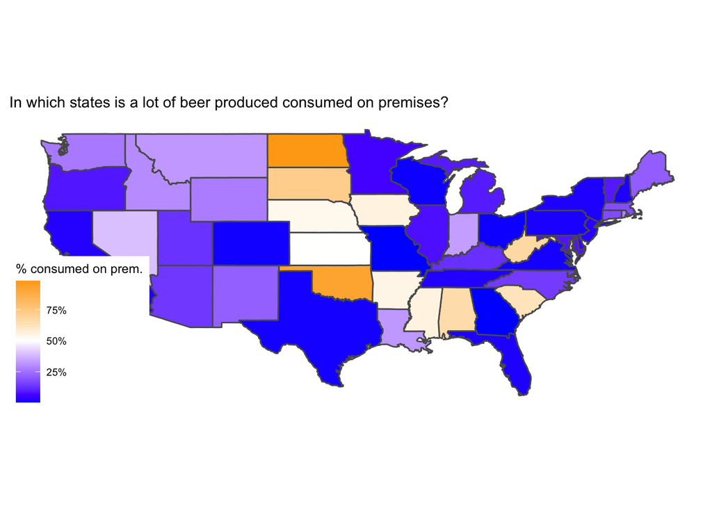

```r
library(maps) #please make sure you install this package using install.packages("maps") in your console!
library(sf) # same here! - install.packages("sf")
states <- st_as_sf(map("state", plot = FALSE, fill = TRUE))
states_joined <- state_percents_2019 %>%
  mutate(ID = str_to_lower(state.name[match(state, state.abb)])) %>%
  inner_join(states, by = "ID")
states_joined %>%
  filter(type == "On Premises") %>%
  ggplot(aes(geometry = geom, fill = percent)) +
  geom_sf() +
  scale_fill_gradient2(low = "blue", high = "orange", midpoint = .5,
                       labels = scales::percent) +
  ggthemes::theme_map() +
  labs(title = "In which states is a lot of beer produced consumed on premises?",
       fill = "% consumed on prem.")
```

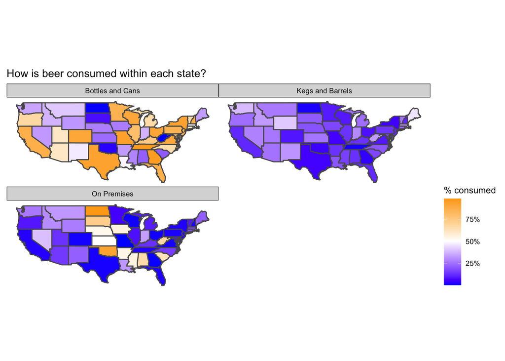

```r
states_joined %>%
  ggplot(aes(geometry = geom, fill = percent)) +
  geom_sf() +
  facet_wrap(~ type, nrow = 2) +
  scale_fill_gradient2(low = "blue", high = "orange", midpoint = .5,
                       labels = scales::percent) +
  ggthemes::theme_map() +
  theme(legend.position = "right") +
  labs(title = "How is beer consumed within each state?",
       fill = "% consumed")
```

Now, let’s do a COOL thing! let’s make it MOVE! with another package `gganimate`

Make sure that you install it first `install.packages("gganimate")`

```r
library(gganimate)
beer_states %>%
  filter(state != "total") %>%
  group_by(state, year) %>%
  mutate(percent = barrels / sum(barrels)) %>%
  ungroup() %>%
  filter(type == "On Premises") %>%
  mutate(ID = str_to_lower(state.name[match(state, state.abb)])) %>%
  inner_join(states, by = "ID") %>%
  ggplot(aes(geometry = geom, fill = percent)) +
  geom_sf() +
  transition_time(year) +
  facet_wrap(~ type, nrow = 2) +
  scale_fill_gradient2(low = "blue", high = "orange", midpoint = .5,
                       labels = scales::percent) +
  ggthemes::theme_map() +
  theme(legend.position = "right") +
  labs(title = "How is beer consumed within each state? ({ as.integer(frame_time) })",
       fill = "% consumed")
```

[output not shown]